# Saving and Loading Models

In this notebook, I'll show you how to save and load models with PyTorch. This is important because you'll often want to load previously trained models to use in making predictions or to continue training on new data.

```python
%matplotlib inline
%config InlineBackend.figure_format = 'retina'

import matplotlib.pyplot as plt

import torch
from torch import nn
from torch import optim
import torch.nn.functional as F
from torchvision import datasets, transforms

import helper
import fc_model
```

```python
# Define a transform to normalize the data
transform = transforms.Compose([transforms.ToTensor(),
                                transforms.Normalize((0.5,), (0.5,))])
# Download and load the training data
trainset = datasets.FashionMNIST('F_MNIST_data/', download=True, train=True, transform=transform)
trainloader = torch.utils.data.DataLoader(trainset, batch_size=64, shuffle=True)

# Download and load the test data
testset = datasets.FashionMNIST('F_MNIST_data/', download=True, train=False, transform=transform)
testloader = torch.utils.data.DataLoader(testset, batch_size=64, shuffle=True)
```

```
Downloading http://fashion-mnist.s3-website.eu-central-1.amazonaws.com/train-images-idx3-ubyte.gz
Downloading http://fashion-mnist.s3-website.eu-central-1.amazonaws.com/train-labels-idx1-ubyte.gz
Downloading http://fashion-mnist.s3-website.eu-central-1.amazonaws.com/t10k-images-idx3-ubyte.gz
Downloading http://fashion-mnist.s3-website.eu-central-1.amazonaws.com/t10k-labels-idx1-ubyte.gz
Processing...
Done!
```

Here we can see one of the images.

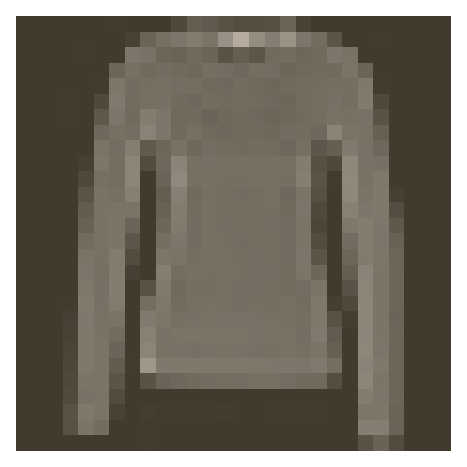

```python
image, label = next(iter(trainloader))
helper.imshow(image[0,:]);
```

# Train a network

To make things more concise here, I moved the model architecture and training code from the last part to a file called `fc_model`. Importing this, we can easily create a fully-connected network with `fc_model.Network`, and train the network using `fc_model.train`. I'll use this model (once it's trained) to demonstrate how we can save and load models.

```python
# Create the network, define the criterion and optimizer

model = fc_model.Network(784, 10, [512, 256, 128])
criterion = nn.NLLLoss()
optimizer = optim.Adam(model.parameters(), lr=0.001)
```

```python
fc_model.train(model, trainloader, testloader, criterion, optimizer, epochs=2)
```

```
Epoch: 1/2..  Training Loss: 1.676..  Test Loss: 0.936..  Test Accuracy: 0.683
Epoch: 1/2..  Training Loss: 1.005..  Test Loss: 0.733..  Test Accuracy: 0.727
Epoch: 1/2..  Training Loss: 0.898..  Test Loss: 0.713..  Test Accuracy: 0.718
Epoch: 1/2..  Training Loss: 0.816..  Test Loss: 0.645..  Test Accuracy: 0.765
Epoch: 1/2..  Training Loss: 0.715..  Test Loss: 0.607..  Test Accuracy: 0.777
Epoch: 1/2..  Training Loss: 0.705..  Test Loss: 0.596..  Test Accuracy: 0.780
Epoch: 1/2..  Training Loss: 0.705..  Test Loss: 0.583..  Test Accuracy: 0.786
Epoch: 1/2..  Training Loss: 0.661..  Test Loss: 0.551..  Test Accuracy: 0.799
Epoch: 1/2..  Training Loss: 0.636..  Test Loss: 0.571..  Test Accuracy: 0.792
Epoch: 1/2..  Training Loss: 0.647..  Test Loss: 0.540..  Test Accuracy: 0.797
Epoch: 1/2..  Training Loss: 0.620..  Test Loss: 0.537..  Test Accuracy: 0.805
Epoch: 1/2..  Training Loss: 0.641..  Test Loss: 0.553..  Test Accuracy: 0.797
Epoch: 1/2..  Training Loss: 0.636..  Test Loss: 0.512..  Test Accuracy: 0.815
Epoch: 1/2..  Training Loss: 0.597..  Test Loss: 0.520..  Test Accuracy: 0.811
Epoch: 1/2..  Training Loss: 0.590..  Test Loss: 0.520..  Test Accuracy: 0.810
Epoch: 1/2..  Training Loss: 0.591..  Test Loss: 0.497..  Test Accuracy: 0.813
Epoch: 1/2..  Training Loss: 0.588..  Test Loss: 0.504..  Test Accuracy: 0.821
Epoch: 1/2..  Training Loss: 0.556..  Test Loss: 0.499..  Test Accuracy: 0.820
Epoch: 1/2..  Training Loss: 0.587..  Test Loss: 0.510..  Test Accuracy: 0.811
Epoch: 1/2..  Training Loss: 0.574..  Test Loss: 0.487..  Test Accuracy: 0.825
Epoch: 1/2..  Training Loss: 0.585..  Test Loss: 0.486..  Test Accuracy: 0.818
Epoch: 1/2..  Training Loss: 0.603..  Test Loss: 0.482..  Test Accuracy: 0.820
Epoch: 1/2..  Training Loss: 0.624..  Test Loss: 0.486..  Test Accuracy: 0.827
Epoch: 2/2..  Training Loss: 0.567..  Test Loss: 0.488..  Test Accuracy: 0.820
Epoch: 2/2..  Training Loss: 0.533..  Test Loss: 0.479..  Test Accuracy: 0.822
Epoch: 2/2..  Training Loss: 0.566..  Test Loss: 0.483..  Test Accuracy: 0.822
Epoch: 2/2..  Training Loss: 0.551..  Test Loss: 0.490..  Test Accuracy: 0.823
Epoch: 2/2..  Training Loss: 0.517..  Test Loss: 0.478..  Test Accuracy: 0.824
Epoch: 2/2..  Training Loss: 0.506..  Test Loss: 0.473..  Test Accuracy: 0.830
Epoch: 2/2..  Training Loss: 0.565..  Test Loss: 0.476..  Test Accuracy: 0.830
Epoch: 2/2..  Training Loss: 0.533..  Test Loss: 0.464..  Test Accuracy: 0.834
Epoch: 2/2..  Training Loss: 0.514..  Test Loss: 0.472..  Test Accuracy: 0.829
Epoch: 2/2..  Training Loss: 0.506..  Test Loss: 0.459..  Test Accuracy: 0.834
Epoch: 2/2..  Training Loss: 0.510..  Test Loss: 0.463..  Test Accuracy: 0.833
Epoch: 2/2..  Training Loss: 0.552..  Test Loss: 0.468..  Test Accuracy: 0.832
Epoch: 2/2..  Training Loss: 0.534..  Test Loss: 0.440..  Test Accuracy: 0.836
Epoch: 2/2..  Training Loss: 0.512..  Test Loss: 0.455..  Test Accuracy: 0.838
Epoch: 2/2..  Training Loss: 0.524..  Test Loss: 0.452..  Test Accuracy: 0.832
Epoch: 2/2..  Training Loss: 0.537..  Test Loss: 0.447..  Test Accuracy: 0.834
Epoch: 2/2..  Training Loss: 0.537..  Test Loss: 0.451..  Test Accuracy: 0.837
Epoch: 2/2..  Training Loss: 0.533..  Test Loss: 0.439..  Test Accuracy: 0.840
Epoch: 2/2..  Training Loss: 0.531..  Test Loss: 0.470..  Test Accuracy: 0.830
Epoch: 2/2..  Training Loss: 0.523..  Test Loss: 0.448..  Test Accuracy: 0.837
Epoch: 2/2..  Training Loss: 0.514..  Test Loss: 0.455..  Test Accuracy: 0.830
Epoch: 2/2..  Training Loss: 0.480..  Test Loss: 0.444..  Test Accuracy: 0.839
Epoch: 2/2..  Training Loss: 0.489..  Test Loss: 0.444..  Test Accuracy: 0.843
```

## Saving and loading networks

As you can imagine, it's impractical to train a network every time you need to use it. Instead, we can save trained networks then load them later to train more or use them for predictions.

The parameters for PyTorch networks are stored in a model's `state_dict`. We can see the state dict contains the weight and bias matrices for each of our layers.

```python
print("Our model: \n\n", model, '\n')
print("The state dict keys: \n\n", model.state_dict().keys())
```

```
Our model:

 Network(
  (hidden_layers): ModuleList(
    (0): Linear(in_features=784, out_features=512, bias=True)
    (1): Linear(in_features=512, out_features=256, bias=True)
    (2): Linear(in_features=256, out_features=128, bias=True)
  )
  (output): Linear(in_features=128, out_features=10, bias=True)
  (dropout): Dropout(p=0.5)
)

The state dict keys:

 odict_keys(['hidden_layers.0.weight', 'hidden_layers.0.bias', 'hidden_layers.1.weight', 'hidden_layers.1.bias', 'hidden_layers.2.weight', 'hidden_layers.2.bias', 'output.weight', 'output.bias'])
```

The simplest thing to do is simply save the state dict with `torch.save`. For example, we can save it to a file `'checkpoint.pth'`.

```python
torch.save(model.state_dict(), 'checkpoint.pth')
```

Then we can load the state dict with `torch.load`.

```python
state_dict = torch.load('checkpoint.pth')
print(state_dict.keys())
```

```
odict_keys(['hidden_layers.0.weight', 'hidden_layers.0.bias', 'hidden_layers.1.weight', 'hidden_layers.1.bias', 'hidden_layers.2.weight', 'hidden_layers.2.bias', 'output.weight', 'output.bias'])
```

And to load the state dict in to the network, you do `model.load_state_dict(state_dict)`.

```python
model.load_state_dict(state_dict)
```

Seems pretty straightforward, but as usual it's a bit more complicated. Loading the state dict works only if the model architecture is exactly the same as the checkpoint architecture. If I create a model with a different architecture, this fails.

```python
# Try this
model = fc_model.Network(784, 10, [400, 200, 100])
# This will throw an error because the tensor sizes are wrong!
model.load_state_dict(state_dict)
```

```
---------------------------------------------------------------------------
RuntimeError                              Traceback (most recent call last)
<ipython-input-17-d859c59ebec0> in <module>()
      2 model = fc_model.Network(784, 10, [400, 200, 100])
      3 # This will throw an error because the tensor sizes are wrong!
----> 4 model.load_state_dict(state_dict)

/opt/conda/lib/python3.6/site-packages/torch/nn/modules/module.py in load_state_dict(self, state_dict, strict)
    719         if len(error_msgs) > 0:
    720             raise RuntimeError('Error(s) in loading state_dict for {}:\n\t{}'.format(
--> 721                                self.__class__.__name__, "\n\t".join(error_msgs)))
    722
    723     def parameters(self):

RuntimeError: Error(s) in loading state_dict for Network:
	While copying the parameter named "hidden_layers.0.weight", whose dimensions in the model are torch.Size([400, 784]) and whose dimensions in the checkpoint are torch.Size([512, 784]).
	While copying the parameter named "hidden_layers.0.bias", whose dimensions in the model are torch.Size([400]) and whose dimensions in the checkpoint are torch.Size([512]).
	While copying the parameter named "hidden_layers.1.weight", whose dimensions in the model are torch.Size([200, 400]) and whose dimensions in the checkpoint are torch.Size([256, 512]).
	While copying the parameter named "hidden_layers.1.bias", whose dimensions in the model are torch.Size([200]) and whose dimensions in the checkpoint are torch.Size([256]).
	While copying the parameter named "hidden_layers.2.weight", whose dimensions in the model are torch.Size([100, 200]) and whose dimensions in the checkpoint are torch.Size([128, 256]).
	While copying the parameter named "hidden_layers.2.bias", whose dimensions in the model are torch.Size([100]) and whose dimensions in the checkpoint are torch.Size([128]).
	While copying the parameter named "output.weight", whose dimensions in the model are torch.Size([10, 100]) and whose dimensions in the checkpoint are torch.Size([10, 128]).
```

This means we need to rebuild the model exactly as it was when trained. Information about the model architecture needs to be saved in the checkpoint, along with the state dict. To do this, you build a dictionary with all the information you need to compeletely rebuild the model.

```python
checkpoint = {'input_size': 784,
              'output_size': 10,
              'hidden_layers': [each.out_features for each in model.hidden_layers],
              'state_dict': model.state_dict()}

torch.save(checkpoint, 'checkpoint.pth')
```

```python
checkpoint
```

[output not shown]

[output cut: 243 more lines]

[output not shown]

```python
def load_checkpoint(filepath):
    checkpoint = torch.load(filepath)
    model = fc_model.Network(checkpoint['input_size'],
                             checkpoint['output_size'],
                             checkpoint['hidden_layers'])
    model.load_state_dict(checkpoint['state_dict'])

    return model
```

```python
model = load_checkpoint('checkpoint.pth')
print(model)
```

```
Network(
  (hidden_layers): ModuleList(
    (0): Linear(in_features=784, out_features=400, bias=True)
    (1): Linear(in_features=400, out_features=200, bias=True)
    (2): Linear(in_features=200, out_features=100, bias=True)
  )
  (output): Linear(in_features=100, out_features=10, bias=True)
  (dropout): Dropout(p=0.5)
)
```